# DS325 Project 3: Recidivism

Johnny Carstens & Matthew Bushnell

12/2/2021

# Introduction

For this project, we are analyzing a criminal justice data set to accurately model and predict recidivism (the likelihood a criminal will reoffend). The data set we are using for these models is from Broward County, Florida and also contains recidivity risk and violence risk scores from a test that the criminals were given. We will build a model with and a model without those scores to determine how helpful the tests really are in predicting recidivity.

Not only will we be creating models on our data set to predict recidivity, we will also be exploring the implications and morality of using algorithms in the criminal justice system. We will also be exploring some additional questions aside from recidivism for this data set.

# Data Cleaning

The data set we were given is exceptionally messy. There are multiple fields that are not useful (date of birth being one) and others that are inusable in their current state (jail in, jail out). The first thing we did was turn jail in and jail out from dates into one column that calculated total days spent in jail. Then we get rid of name and dob. After that we got rid of other variables based upon our needs for the specific models we created.

# Logistic Regression of Recidivism Data

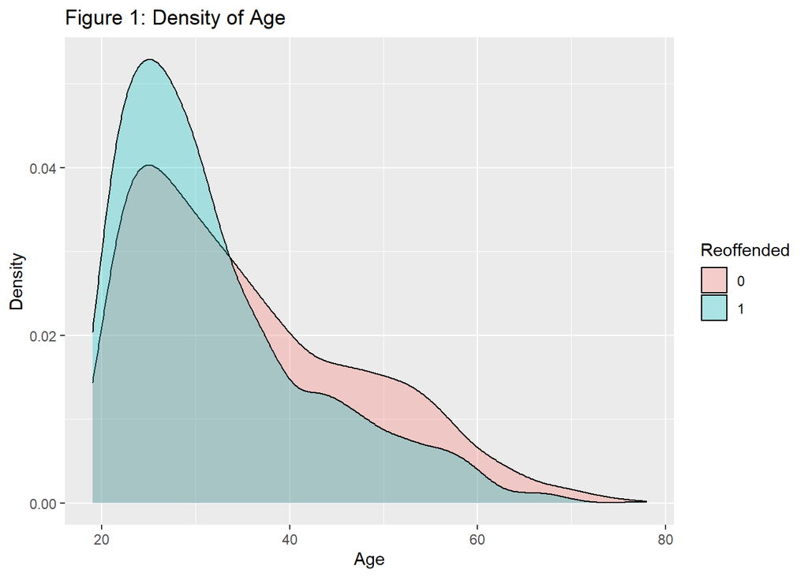

```r
library(tidyverse)
library(olsrr)
library(ggfortify)
library(GGally)
library(mdsr)
data <- read.csv("Project3Sample4000.csv")

pairs <- data %>% select(!c(name,dob, c_jail_in, c_jail_out, RiskRecidScreeningDate,c_charge_desc))

Originaldata <- read.csv("Project3Sample4000.csv")

############### Matt's code
data <- Originaldata %>%
  separate(c_jail_in, c("inDay","inMonth","inYear")) %>%
  separate(c_jail_out,c("outDay","outMonth","outYear")) %>%
  mutate(
    daysInJail = ((as.integer(outYear)*365)+(as.integer(outMonth)*30)+(as.integer(outDay)))-((as.integer(inYear)*365)+(as.integer(inMonth)*30)+(as.integer(inDay)))
  ) %>%
  select(!c(name, dob, inDay, inMonth, inYear, outDay, outMonth, outYear, RiskRecidScreeningDate, c_charge_desc)) %>%
  mutate(
    crimeType = str_extract(c_charge_degree,"[MF]")
  ) %>%
  filter(
    !is.na(crimeType)
  ) %>%
  select(!c(RiskViolenceDecileScore,crimeType,c_charge_degree,race,juvFelonyCount,juvMisdemeanerCount,juvOtherCount,ageCat,days_b_screening_arrest,c_days_from_compas,RiskRecidScoreLevel,RiskViolenceScoreLevel))


ggplot(pairs, aes(x = age, fill = as.factor(isRecid))) +
  geom_density(alpha=.3) +
  labs(x = "Age", y = "Density", title = "Figure 1: Density of Age", fill="Reoffended")
```

Figure 1 is a density plot of Age vs Reoffenders. Reoffend is a binary response variable where 1 is equal to a person who did reoffend, and 0 is equal to someone who hasn’t reoffended. Notice that in Figure 1, as age increases the amount of people who reoffended, or didn’t reoffend decreases. We can also see that between ages 30 and 35, the amount of people who didn’t recidivate becomes greater than those who did recidivate. It makes sense to see older individuals become less inclined towards reoffending while younger individuals have a greater inclination towards reoffending. Perhaps one of the reasons why older individuals are less inclined to reoffending is because of extensive time spent in incarceration. Age looks like a good variable to use in our model.

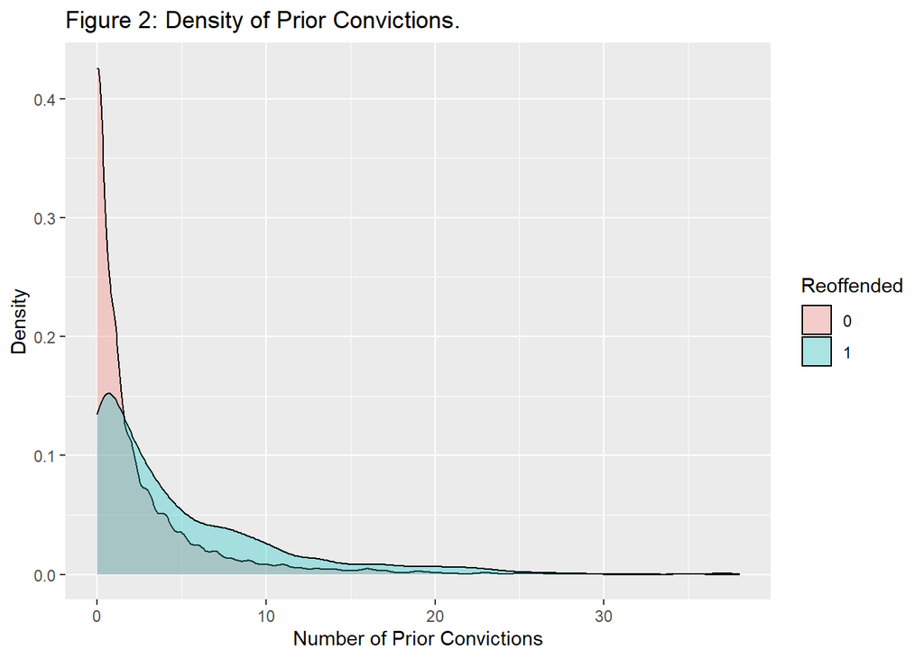

```r
ggplot(pairs, aes(x=priorsCount, fill=as.factor(isRecid))) +
  geom_density(alpha=.3) +
  labs(x="Number of Prior Convictions", y = "Density", title = "Figure 2: Density of Prior Convictions.", fill = "Reoffended")
```

Figure 2 is a density plot of the number of prior convictions who did and did not recidivate. It is clear that those who have never committed a prior crime are much less likely to reoffend. This data is fairly skewed, so we apply the natural log function to the number of prior convictions which brings us to the next plot.

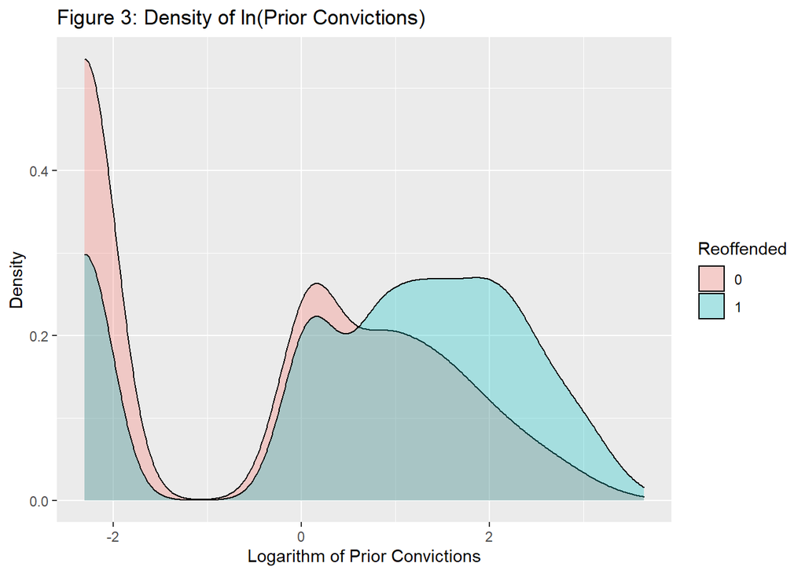

```r
ggplot(pairs, aes(x=log(priorsCount+0.1), fill=as.factor(isRecid))) +
  geom_density(alpha=.3) +
  labs(x="Logarithm of Prior Convictions", y = "Density", title = "Figure 3: Density of ln(Prior Convictions)", fill = "Reoffended")
```

Figure 3 is the same plot as figure 2, except we added 0.1 to the number of prior convictions and then applied a natural logarithm to the data column. We can see that the distribution has been normalized better compared to Figure 2. We shall use this process of using the natural logarithm when building our logistic regression model. The peak on the left side of the data represents individuals who had 0 prior convictions while the next bump over the valley represents those who had 1 or more. The reason for the valley in between is because of the nature of logarithms and the fact that we had to add 0.1 to the values of 0 in order to get defined numbers. We can see that individuals who had 1 prior were slightly less likely to reoffend while those with more than 1 greatly increased their recidivity risk.

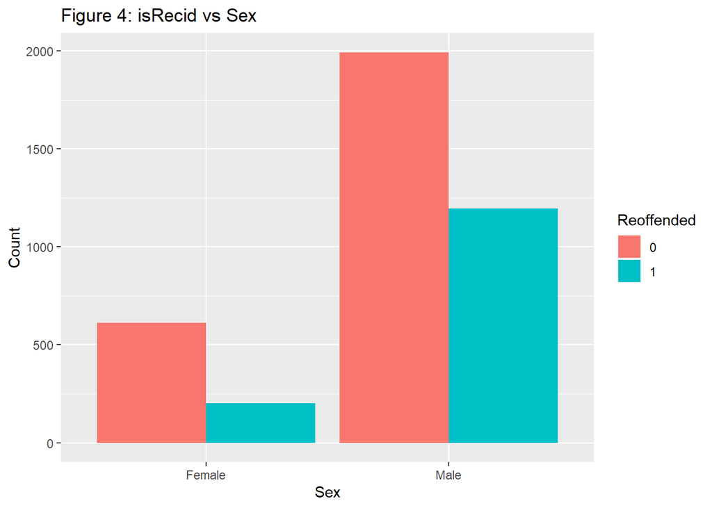

```r
ggplot(pairs, aes(x=sex, fill = as.factor(isRecid))) + geom_bar(position = "dodge") +
  labs(x = "Sex", y = "Count", title = "Figure 4: isRecid vs Sex",fill="Reoffended")
```

Figure 4 is a bar graph of Sex vs Reoffended. First we note that the male category is much larger. This plot also shows that less than a third of females are likely to reoffend while greater than a third of men are likely to reoffend. This information can be useful to our model.

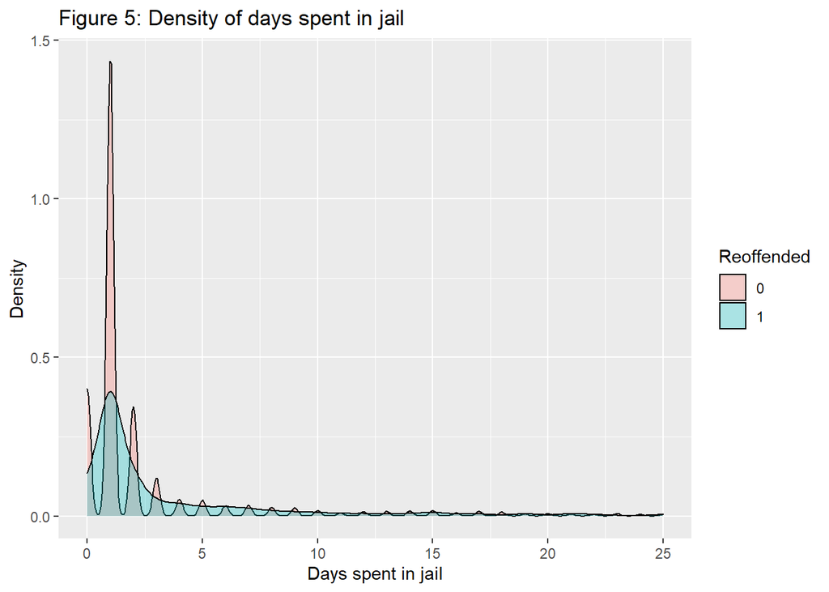

```r
ggplot(data=data,aes(x=daysInJail,fill=as.factor(isRecid))) +
  geom_density(alpha=.3) +
  labs(x="Days spent in jail",y="Density",fill="Reoffended",title="Figure 5: Density of days spent in jail") +
  xlim(0,25)
```

# Building Logistic Regession Models for Classification

The data set provided contained a variable called RiskRecidDecileScore. This score came from convicts taking a test that determined how likey they are to recidivate on a scale of 1-10. We built one model that includes the RiskRecidDecileScore and one model without the score. The first model we built does not include RiskRecidDecileScore in our prediction variables.

```r
modelNSdata <- data %>% select(!RiskRecidDecileScore)
modelNS <- glm(data=modelNSdata,isRecid~sex+age+daysInJail+log(priorsCount+.1),family="binomial")
```

### Model with no scores

#### Simple

| Variable | Value |
| --- | --- |
| Intercept | 0.2742972 |
| Sex=Male | 0.4733131 |
| Age | -0.0372059 |
| Days In Jail | -0.0027707 |
| Natural Log of Priors | 0.3705684 |

#### Full Summary

```r
summary(modelNS)
```

```
##
## Call:
## glm(formula = isRecid ~ sex + age + daysInJail + log(priorsCount +
##     0.1), family = "binomial", data = modelNSdata)
##
## Deviance Residuals:
##     Min       1Q   Median       3Q      Max
## -1.5286  -0.9179  -0.6283   1.1072   2.6914
##
## Coefficients:
##                          Estimate Std. Error z value Pr(>|z|)
## (Intercept)             0.2742972  0.1397136   1.963   0.0496 *
## sexMale                 0.4733131  0.0950040   4.982 6.29e-07 ***
## age                    -0.0372059  0.0033943 -10.961  < 2e-16 ***
## daysInJail             -0.0027707  0.0006074  -4.562 5.07e-06 ***
## log(priorsCount + 0.1)  0.3705684  0.0212539  17.435  < 2e-16 ***
## ---
## Signif. codes:  0 '***' 0.001 '**' 0.01 '*' 0.05 '.' 0.1 ' ' 1
##
## (Dispersion parameter for binomial family taken to be 1)
##
##     Null deviance: 5104.1  on 3943  degrees of freedom
## Residual deviance: 4616.3  on 3939  degrees of freedom
##   (54 observations deleted due to missingness)
## AIC: 4626.3
##
## Number of Fisher Scoring iterations: 4
```

#### Error

```r
modelNSPred <- predict.glm(modelNS,newdata=data,type="response")


dataWNSPred  <- cbind(data,modelNSPred)

dataWNSPred <- dataWNSPred %>%
  mutate(
    recidPred = ifelse(modelNSPred > .5, 1, 0)
  )

WNSmatrix <- table(dataWNSPred$recidPred,dataWNSPred$isRecid)
```

[output not shown]

$$\textrm{Error Rate} = \frac{CF_{12} + CF_{21}}{n},\textrm{ where i = row, j = column, and n = number of observations.}$$

Using our Error Rate formula and plugging in values from our confusion matrix gives us
$$\textrm{Error Rate} = 0.2958979$$

#### Equation

$$\textrm{recidivation odds} = e^{0.274}\cdot e^{0.473_{sex=Male}}\cdot e^{-0.037_{age}}\cdot e^{-.0028_{daysInJail}}\cdot e^{0.371ln(priors)}$$

**—————————————————————————**

Above is a summary of the logistic model created to predict whether or not a convict will recidivate. If we check the full summery tab we can see that all of our variables are statistically significant.

Our equation will give us the odds of a criminal recidivating. The variable constants may seem small but they are exponents, any small change to them will change the odds by no small factor.

Our error rate is the percentage of data points that our model got wrong.

Now we will build a model using the recidivism scores that we were given with the data set. This will help determine if the scores are effective or not.

```r
modelWS <- glm(data=data,isRecid~+sex+age+RiskRecidDecileScore+daysInJail+log(priorsCount+.1),family="binomial")

modelWSPred <- predict.glm(modelWS,newdata=data,type="response")


dataWSPred  <- cbind(data,modelWSPred)

dataWSPred <- dataWSPred %>%
  mutate(
    recidPred = ifelse(modelWSPred > .5, 1, 0)
  )

WSmatrix <- table(dataWSPred$recidPred,dataWSPred$isRecid)
```

### Model with scores

#### Simple

| Variable | Value |
| --- | --- |
| Intercept | -1.0428542 |
| Sex=Male | 0.5076367 |
| Age | -0.0202713 |
| Risk Recid Decile Score | 0.16366 |
| Days In Jail | -0.0040754 |
| Natural Log of Priors | 0.2606601 |

#### Full Summary

```r
summary(modelWS)
```

```
##
## Call:
## glm(formula = isRecid ~ +sex + age + RiskRecidDecileScore + daysInJail +
##     log(priorsCount + 0.1), family = "binomial", data = data)
##
## Deviance Residuals:
##     Min       1Q   Median       3Q      Max
## -1.7458  -0.8710  -0.5948   1.0530   2.7109
##
## Coefficients:
##                          Estimate Std. Error z value Pr(>|z|)
## (Intercept)            -1.0428542  0.1874145  -5.564 2.63e-08 ***
## sexMale                 0.5076367  0.0963774   5.267 1.39e-07 ***
## age                    -0.0202713  0.0037228  -5.445 5.17e-08 ***
## RiskRecidDecileScore    0.1636600  0.0154727  10.577  < 2e-16 ***
## daysInJail             -0.0040754  0.0006555  -6.217 5.07e-10 ***
## log(priorsCount + 0.1)  0.2606601  0.0233473  11.164  < 2e-16 ***
## ---
## Signif. codes:  0 '***' 0.001 '**' 0.01 '*' 0.05 '.' 0.1 ' ' 1
##
## (Dispersion parameter for binomial family taken to be 1)
##
##     Null deviance: 5104.1  on 3943  degrees of freedom
## Residual deviance: 4503.0  on 3938  degrees of freedom
##   (54 observations deleted due to missingness)
## AIC: 4515
##
## Number of Fisher Scoring iterations: 4
```

#### Error

[output not shown]

$$\textrm{Error Rate} = 0.2926463$$

#### Equation

$$\textrm {Recidivation odds} = e^{-1.043}\cdot e^{0.508_{sex=male}}\cdot e^{-0.02_{age}}\cdot e^{0.164_{RiskRecidDecileScore}}\cdot e^{-0.004_{daysInJail}}\cdot e^{0.261_{ln(priors)}}$$

**—————————————————————————**

Above is a summary of the logistic model created to predict whether or not a convict will recidivate. If we check the full summery tab we can see that all of our variables are statistically significant. We also have the error tab and the equation tab.

Our model is better with the RiskRecidDecileScore, meaning that the test the criminals were given to predict recidivation rates was helpful in constructing a predictive model.

### Summerizing our logistic regression models

The null model for our recidivism prediction would be to take our data and find whatever category was most common for recidivation (in this case it is most common to not recidivate) and simply predict that every criminal won’t recidivate. This would give us an error of $0.3482$ meaning that 34% of criminals that we predicted would not recidivate did revidivate. Both of our models had an error rate of about 29%, meaning that our models were about 5% better than just guessing. This isn’t ideal, but it is better. However, we find it unsatisfactory when considering that a model like this, if put into use, could effect the outcome of a criminal’s ability to receive parole. We wouldn’t be comfortable using any model with something so important and sensetive unless we had a lower error rate.

# Multiple Regression Models

In this section we are trying to predict the scores for recidivism that the convicts received from their test. These scores range from 1-10 for recidivism risk and violence risk.

### Model for Predicting Recedivism Risk

#### Simple

```r
bestModel <- lm(RiskRecidDecileScore ~ age + race + juvFelonyCount + juvOtherCount + priorsCount, data=Originaldata)
```

| Variable | Value |
| --- | --- |
| Intercept | 7.3706373 |
| Age | -0.0988189 |
| Race=Hispanic | -1.1647881 |
| Race=Other | -1.316598 |
| Race=White | -0.830127 |
| Juvenile Felony Count | 0.3370698 |
| Juvenile Other Count | 0.2788127 |
| Priors Count | 0.2723405 |

#### Full Summery

```r
summary(bestModel)
```

```
##
## Call:
## lm(formula = RiskRecidDecileScore ~ age + race + juvFelonyCount +
##     juvOtherCount + priorsCount, data = Originaldata)
##
## Residuals:
##     Min      1Q  Median      3Q     Max
## -7.6013 -1.5759 -0.3036  1.3946  7.0644
##
## Coefficients:
##                 Estimate Std. Error t value Pr(>|t|)
## (Intercept)     7.370637   0.111331  66.205  < 2e-16 ***
## age            -0.098819   0.003068 -32.212  < 2e-16 ***
## racehispanic   -1.164788   0.128619  -9.056  < 2e-16 ***
## raceother      -1.316598   0.139778  -9.419  < 2e-16 ***
## racewhite      -0.830127   0.078533 -10.570  < 2e-16 ***
## juvFelonyCount  0.337070   0.087208   3.865 0.000113 ***
## juvOtherCount   0.278813   0.082230   3.391 0.000704 ***
## priorsCount     0.272341   0.007793  34.945  < 2e-16 ***
## ---
## Signif. codes:  0 '***' 0.001 '**' 0.01 '*' 0.05 '.' 0.1 ' ' 1
##
## Residual standard error: 2.154 on 3992 degrees of freedom
## Multiple R-squared:  0.4329, Adjusted R-squared:  0.4319
## F-statistic: 435.3 on 7 and 3992 DF,  p-value: < 2.2e-16
```

#### Error

$$\textrm {RMSE} = 2.151787$$

#### Equation

$$\textrm {Risk Recid Decile Score} = 7.371 - 0.099_{age} - 1.165_{race=hispanic} - 1.317_{race=other} - 0.83_{race=white} + 0.337_{juvFelonyCount} + 0.279_{juvOtherCount} + 0.272_{priors}$$

**—————————————————————————**

### Model for Predicting Violence Risk

#### Simple

```r
pleaseGodHelp <- Originaldata %>%
  select(!c(c_charge_degree,c_charge_desc,name,dob,RiskRecidScreeningDate,c_jail_in,c_jail_out,RiskViolenceScoreLevel, isRecid, ageCat, RiskRecidScoreLevel, RiskRecidDecileScore, RiskViolenceScoreLevel, c_days_from_compas, days_b_screening_arrest))

byron <- lm(RiskViolenceDecileScore ~ ., pleaseGodHelp)
```

| Variable | Value |
| --- | --- |
| Intercept | 7.222521 |
| Sex=Male | 0.471441 |
| Age | -0.1187966 |
| Race=Hispanic | -0.772289 |
| Race=Other | -0.8552049 |
| Race=White | -0.6499971 |
| Juvenile Felony Count | 0.3698574 |
| Juvenile Misdemeaner Count | 0.1387014 |
| Juvenile Other Count | 0.31522 |
| Priors Count | 0.1230222 |

#### Full Summery

```r
summary(byron)
```

```
##
## Call:
## lm(formula = RiskViolenceDecileScore ~ ., data = pleaseGodHelp)
##
## Residuals:
##     Min      1Q  Median      3Q     Max
## -7.3630 -1.3519 -0.2881  1.0384  8.8398
##
## Coefficients:
##                      Estimate Std. Error t value Pr(>|t|)
## (Intercept)          7.222521   0.109420  66.007  < 2e-16 ***
## sexMale              0.471441   0.072712   6.484 1.00e-10 ***
## age                 -0.118797   0.002615 -45.434  < 2e-16 ***
## racehispanic        -0.772289   0.109353  -7.062 1.92e-12 ***
## raceother           -0.855205   0.118799  -7.199 7.23e-13 ***
## racewhite           -0.649997   0.066776  -9.734  < 2e-16 ***
## juvFelonyCount       0.369857   0.074144   4.988 6.35e-07 ***
## juvMisdemeanerCount  0.138701   0.063528   2.183   0.0291 *
## juvOtherCount        0.315220   0.074289   4.243 2.25e-05 ***
## priorsCount          0.123022   0.006902  17.824  < 2e-16 ***
## ---
## Signif. codes:  0 '***' 0.001 '**' 0.01 '*' 0.05 '.' 0.1 ' ' 1
##
## Residual standard error: 1.83 on 3990 degrees of freedom
## Multiple R-squared:  0.4528, Adjusted R-squared:  0.4516
## F-statistic: 366.9 on 9 and 3990 DF,  p-value: < 2.2e-16
```

#### Error

$$\textrm {RMSE} = 1.828036$$

#### Equation

$$\textrm {Risk Violence Decile Score} = 7.223 + 0.471_{sex=male} - 0.119_{age} - 0.772_{race=hispanic}-0.855_{race=other}-0.650_{race=white}+0.370_{juvFelonyCount}+0.139_{juvMisdemeanerCount}+0.315_{juvOtherCount}+0.123_{priors}$$

**—————————————————————————**

Our RMSE is better for predicting violence than it is for predicting recidivism. Our recidivation model doesn’t account for gender which is probably a good indication of violence in our violence model. This probably means that whatever test the criminals take accounts for male’s being more prone to violence. If a criminal is a male in our model, it adds .47 points to their violence score. Interestingly, the score starts out pretty high (7.222 according to the intercept) and is subtracted from only on account of age and race. A criminal will have a low violence score if they are an elderly woman of a race other than hispanic, black, or white.

# Classification models for two subpopulations.

Looking at our data from Broward County we can see that there is a much larger amount of males when compared to females. Let us make a classification model for each gender and see how they compare to each other.

```r
males <- read.csv("Project3Males1500.csv")
females <- read.csv("Project3Females1500.csv")

fdf <- females %>%
  separate(c_jail_in, c("inDay","inMonth","inYear")) %>%
  separate(c_jail_out,c("outDay","outMonth","outYear")) %>%
  mutate(
    daysInJail = ((as.integer(outYear)*365)+(as.integer(outMonth)*30)+(as.integer(outDay)))-((as.integer(inYear)*365)+(as.integer(inMonth)*30)+(as.integer(inDay)))
  ) %>%
  select(!c(name, dob, inDay, inMonth, inYear, outDay, outMonth, outYear, RiskRecidScreeningDate, c_charge_desc)) %>%
  mutate(
    crimeType = str_extract(c_charge_degree,"[MF]")
  ) %>%
  filter(
    !is.na(crimeType)
  ) %>%
  select(!c(daysInJail,juvMisdemeanerCount,juvFelonyCount,juvOtherCount,c_charge_degree,race,sex,RiskViolenceDecileScore,crimeType,ageCat,days_b_screening_arrest,c_days_from_compas,RiskRecidScoreLevel,RiskViolenceScoreLevel))

mdf <- males %>%
  separate(c_jail_in, c("inDay","inMonth","inYear")) %>%
  separate(c_jail_out,c("outDay","outMonth","outYear")) %>%
  mutate(
    daysInJail = ((as.integer(outYear)*365)+(as.integer(outMonth)*30)+(as.integer(outDay)))-((as.integer(inYear)*365)+(as.integer(inMonth)*30)+(as.integer(inDay)))
  ) %>%
  select(!c(name, dob, inDay, inMonth, inYear, outDay, outMonth, outYear, RiskRecidScreeningDate, c_charge_desc)) %>%
  mutate(
    crimeType = str_extract(c_charge_degree,"[MF]")
  ) %>%
  filter(
    !is.na(crimeType)
  ) %>%
  select(!c(juvMisdemeanerCount,juvFelonyCount,juvOtherCount,c_charge_degree,race,sex,RiskViolenceDecileScore,crimeType,ageCat,days_b_screening_arrest,c_days_from_compas,RiskRecidScoreLevel,RiskViolenceScoreLevel))

fmodel <- glm(data=fdf,isRecid~.,family="binomial")

mmodel <- glm(data=mdf,isRecid~.,family="binomial")
```

### Model for females

#### Simple

| Variable | Value |
| --- | --- |
| Intercept | -1.586004 |
| Age | -0.0128805 |
| Priors | 0.1504766 |
| Risk Recid Score | 0.1410503 |

#### Full Summary

```r
summary(fmodel)
```

```
##
## Call:
## glm(formula = isRecid ~ ., family = "binomial", data = fdf)
##
## Deviance Residuals:
##     Min       1Q   Median       3Q      Max
## -1.9682  -0.7405  -0.5888   0.3845   2.1546
##
## Coefficients:
##                       Estimate Std. Error z value Pr(>|z|)
## (Intercept)          -1.586004   0.304116  -5.215 1.84e-07 ***
## age                  -0.012880   0.007011  -1.837   0.0662 .
## priorsCount           0.150477   0.022999   6.543 6.05e-11 ***
## RiskRecidDecileScore  0.141050   0.029463   4.787 1.69e-06 ***
## ---
## Signif. codes:  0 '***' 0.001 '**' 0.01 '*' 0.05 '.' 0.1 ' ' 1
##
## (Dispersion parameter for binomial family taken to be 1)
##
##     Null deviance: 1700.1  on 1499  degrees of freedom
## Residual deviance: 1539.6  on 1496  degrees of freedom
## AIC: 1547.6
##
## Number of Fisher Scoring iterations: 4
```

#### Error

```r
fmodelPred <- predict.glm(fmodel,newdata=fdf,type="response")


fDataPred  <- cbind(fdf,fmodelPred)

fDataPred <- fDataPred %>%
  mutate(
    recidPred = ifelse(fmodelPred > .5, 1, 0)
  )

fmatrix <- table(fDataPred$recidPred,fDataPred$isRecid)
```

[output not shown]

Error rate: 0.2426667

Null hypothesis error: 0.254

#### Equation

$$\textrm {Odds of Recidivation} = e^{-1.586}\cdot e^{-0.013_{age}}\cdot e^{0.150_{priors}}\cdot e^{0.141_{RiskRecidDecileScore}}$$

**—————————————————————————**

Above we have our model for predicting recidivism in females. The model isn’t very good, considering how it is only about .01 or 1% better than our null hypothesis.

### Model for males

#### Simple

[output not shown]

#### Full Summary

```r
summary(mmodel)
```

```
##
## Call:
## glm(formula = isRecid ~ ., family = "binomial", data = mdf)
##
## Deviance Residuals:
##     Min       1Q   Median       3Q      Max
## -2.3346  -0.9422  -0.5995   1.1055   2.5948
##
## Coefficients:
##                        Estimate Std. Error z value Pr(>|z|)
## (Intercept)          -0.0379772  0.2650427  -0.143   0.8861
## age                  -0.0391582  0.0063407  -6.176 6.59e-10 ***
## priorsCount           0.0957135  0.0149355   6.408 1.47e-10 ***
## RiskRecidDecileScore  0.1385292  0.0252348   5.490 4.03e-08 ***
## daysInJail           -0.0027381  0.0007979  -3.432   0.0006 ***
## ---
## Signif. codes:  0 '***' 0.001 '**' 0.01 '*' 0.05 '.' 0.1 ' ' 1
##
## (Dispersion parameter for binomial family taken to be 1)
##
##     Null deviance: 1983.8  on 1480  degrees of freedom
## Residual deviance: 1755.2  on 1476  degrees of freedom
##   (19 observations deleted due to missingness)
## AIC: 1765.2
##
## Number of Fisher Scoring iterations: 4
```

#### Error

```r
mmodelPred <- predict.glm(mmodel,newdata=mdf,type="response")


mDataPred  <- cbind(mdf,mmodelPred)

mDataPred <- mDataPred %>%
  mutate(
    recidPred = ifelse(mmodelPred > .5, 1, 0)
  )

mmatrix <- table(mDataPred$recidPred,mDataPred$isRecid)
```

[output not shown]

Error rate: 0.3133333

Null hypothesis error: 0.392

#### Equation

$$\textrm {Odds of Recidivation} = e^{-0.038}\cdot e^{-0.039_{age}}\cdot e^{0.096_{priors}}\cdot e^{0.139_{RiskRecidDecileScore}}\cdot e^{-0.003_{daysInJail}}$$

**—————————————————————————**

# Another story about criminal justice

In our data set we were given date of birth for each individual. We wondered if there was anything to astrology, so we engineered a column for the birth signs for each criminal. Below are some plots we made with this data.

```r
library(arules)


extraData <- Originaldata %>%
  separate(c_jail_in, c("inDay","inMonth","inYear")) %>%
  separate(c_jail_out,c("outDay","outMonth","outYear")) %>%
  mutate(
    daysInJail = ((as.integer(outYear)*365)+(as.integer(outMonth)*30)+(as.integer(outDay)))-((as.integer(inYear)*365)+(as.integer(inMonth)*30)+(as.integer(inDay)))
  ) %>%
  select(!c(name, inDay, inMonth, inYear, outDay, outMonth, outYear, RiskRecidScreeningDate, c_charge_desc)) %>%
  mutate(
    crimeType = str_extract(c_charge_degree,"[MF]")
  ) %>%
  filter(
    !is.na(crimeType)
  ) %>%
  separate(dob, c("birthDay","birthMonth")) %>%
  mutate(
    birthMonth = as.integer(str_remove(birthMonth,"^0+")),
    birthDay = as.integer(birthDay)
  ) %>%
  mutate(
    birthSign = case_when(
      (birthMonth == 1 & birthDay > 19) | (birthMonth == 2 & birthDay < 19) ~ "Aquarius",
      (birthMonth == 2 & birthDay > 18) | (birthMonth == 3 & birthDay < 21) ~ "Pisces",
      (birthMonth == 3 & birthDay > 20) | (birthMonth == 4 & birthDay < 20) ~ "Aries",
      (birthMonth == 4 & birthDay > 19) | (birthMonth == 5 & birthDay < 21) ~ "Taurus",
      (birthMonth == 5 & birthDay > 20) | (birthMonth == 6 & birthDay < 21) ~ "Gemini",
      (birthMonth == 6 & birthDay > 21) | (birthMonth == 7 & birthDay < 23) ~ "Cancer",
      (birthMonth == 7 & birthDay > 22) | (birthMonth == 8 & birthDay < 23) ~ "Leo",
      (birthMonth == 8 & birthDay > 22) | (birthMonth == 9 & birthDay < 23) ~ "Virgo",
      (birthMonth == 9 & birthDay > 22) | (birthMonth == 10 & birthDay < 23) ~ "Libra",
      (birthMonth == 10 & birthDay > 22) | (birthMonth == 11 & birthDay < 22) ~ "Scorpius",
      (birthMonth == 11 & birthDay > 21) | (birthMonth == 12 & birthDay < 22) ~ "Sagittarius",
      (birthMonth == 12 & birthDay > 21) | (birthMonth == 1 & birthDay < 20) ~ "Capricorn"
    )) %>%
  select(!c(birthDay, birthMonth, crimeType,c_charge_degree,ageCat,days_b_screening_arrest,c_days_from_compas,RiskRecidScoreLevel,RiskViolenceScoreLevel)) %>%
  filter(!is.na(birthSign))
```

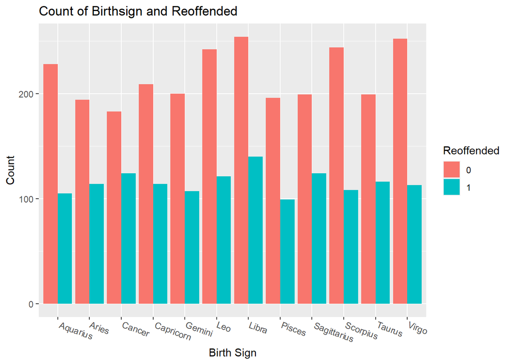

```r
ggplot(data=extraData,aes(x=birthSign, fill=as.factor(isRecid))) +
  geom_bar(position="dodge") +
  labs(title="Count of Birthsign and Reoffended",x="Birth Sign",y="Count",fill="Reoffended") +
  theme(axis.text.x=element_text(angle =- 20,hjust=-.1))
```

The plot above shows the count of those who reoffended by their birth signs. As one would expect, there isn’t any conclusive evidence that any of the birthsigns are more commonly criminal or more likely to recidivate. However, the plot below offers some more interesting insight.

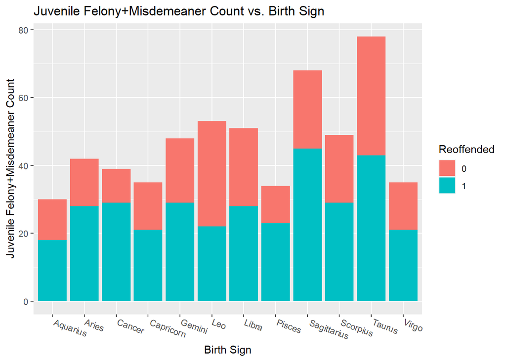

```r
ggplot(data=extraData,aes(x=birthSign,y=juvFelonyCount+juvMisdemeanerCount,fill=as.factor(isRecid)))+
  geom_col() +
  labs(fill="Reoffended", title="Juvenile Felony+Misdemeaner Count vs. Birth Sign", x="Birth Sign", y="Juvenile Felony+Misdemeaner Count") +
  theme(axis.text.x=element_text(angle =- 20,hjust=-.1))
```

At first glance that might be a pretty poor factor to include in a model. However, there is an OECD study that suggests the month a child is born in has a factor in the success of a child in school. While we can confidently say a child’s birth sign doesn’t immediately affect their chances of being criminal, what month a child is born in shouldn’t be discounted. Education and success in school is related to chances of criminal activity. When we make a model off of human behavior it can be hard to predict what is and isn’t significant. On one hand we could have tried to give credit to astrology to predict juvenile felonies. On the other hand we could have completely discredited birth month when it has been proven to have an effect on students. Predicted human behavior can be difficult and the lines between what is ethical and unethical can be blurry. As data scientists we should be careful when we approach a problem that predicts human behavior.

# Works Cited

https://read.oecd-ilibrary.org/education/how-student-s-month-of-birth-is-linked-to-performance-at-school_822ea6ce-en#page20

https://www.propublica.org/article/machine-bias-risk-assessments-in-criminal-sentencing

https://criminal-justice.iresearchnet.com/crime/education-and-crime/4/